# Meat consumption trends 1995–2020

Tomasz Przechlewski

2023

## Introduction

This meat consumptions trends are generally regarded as harmful and the potential negative consequences of substituting meat for traditional foods are threefold:

- meat consumption is unhealthy (for consumers),
- meat production is economically inefficient (compared to plant-based food),
- meat production is harmful to environment being substantial source both of greenhouse gases and land degradation

Ever-increased number of papers warns that following the path of fast increasing meat consumption results in both environment and global economic catastrophe. Looking for possible soft-solutions (hard solution is a degrowth strategies) Vrenken et all (2014) based on EKC hypothesis looked for `turning point’ in meat consumption and claimed they found one. The other paper which claimed that meat consumption follows EKC is of Cole and McCoskey (2013).

The aim of the study is to assess the trends in world meat consumption in last 60 years based on data from FAO food balance sheet. As it is assumed that the total meat consumption depends on income the consumptions is compared by World Bank’s income groups. Finally two simple models namely Engel Curve, and Environment Kuznets Curve (EKC) hypothesis are tested and the results discussed with the above mentioned previous reports.

In particular both papers cited above are pretty dated and do not cover the last decade. Using the same data (FAO Food balance sheet) we try to verify if after ten years of ever-increased warnings, social-awareness and pro-environmental propaganda the world is closer to those `turning points’?

## Data

### FBS

We use data on food consumption and population from Food Balance Sheet (https://www.fao.org/faostat/en/#data/FBS) provided by the UN Organization for Food and Agriculture (FAO.)

FBS data on per capita and total of food supply are calculated as follows:

**(production + import + stocks) - (export + feeding/non-food-usage/wastage + closing stocks)**

The difference divided by population is per capita consumption

FBS is divided into hundreds of items (such as pepper or onion) and many item groups (such as Meat or Animal Products.)

Items/Item groups are measured as:

1. yearly per capita **quantity supply** (kilograms/per capita/year, abbreviated to kg/c/y )
2. daily per capita **energy supply** (**kilocalories/per capita/daily**, kcal/c/d),
3. daily per capita **quantity supply** (grams/per capita/day, g/c/d),
4. yearly total **quantity supply** (1000 tonnes)

We analyze the three groups: **meat**, **total intake** and **total protein supply** (ie animal and plan based protein). **Meat consumption** was measured with 1, 2 and 4; **total intake** was measured with 2; and **total protein supply** is measured with 3.

### World Bank

To verify hipothesis on the relation between income and meat/total consumption we use data on GDP from the World Bank, namely we use GNI per capita (Atlas method in current USD; https://data.worldbank.org/indicator/NY.GNP.PCAP.CD)

World Bank per-capita income groups (2022) are listed in table 1.

Table 1. World Bank income groups

| GNI pc | Income group |
| --- | --- |
| 0–1084 | low |
| 1085–4254 | lower-middle |
| 4255–13204 | upper-middle |
| 13205– | high |

Source: https://blogs.worldbank.org/opendata/new-world-bank-country-classifications-income-level-2022-2023

### The database

The country with population less than 3mln was dropped from the analysis with about 130 countries left in the sample.

The balance is mantained from 1961 but in 2010 there was a methodology change.  
The new FBS is published from 2010 but for 2010–2013 period FAO published both versions. We computed averages of meat consumption in kg/per capita for this period (ie 2010–2013) for new and old FBS. In case of difference higher then 10%, the data was regarded as unreliable and the country was dropped from our panel. Only 105 countries left in the sample (the list of countries dropped can be found online at our github page) but these countries consumed 92.3% of total world meat supply in 2020.

When combined with GDP data from World Bank it appeared that there is no GDP data for 3 countries (China Taiwan Province of, Democratic People’s Republic of Korea, South Sudan). Finally our sample contains 102 countries (which nevertheless consumed 90.7% of the total world meat supply in 2020.)

This database is used at exploratory analysis stage. To verify income-consumption relation we further restrict our sample. As both FBS and World Bank data contains many missing or unreliable (political changes) values we decided to use data from 1995 onward period. Thus our final panel contains 102 countries for 1995–2020.

## Results

### Exploratory analysis

Both protein and total intake rose steadily over the analysed period (cf figure 1). Protein consumption over the period 1961–2010 rose by 0.6% yearly on average, from 61.46 to 79.63 (g/c/d). Slight increase was observed over 2010–2020 period. The protein intake rose from 79.63 in 2010 to 84.57 in 2020 (0.6% yearly on average)

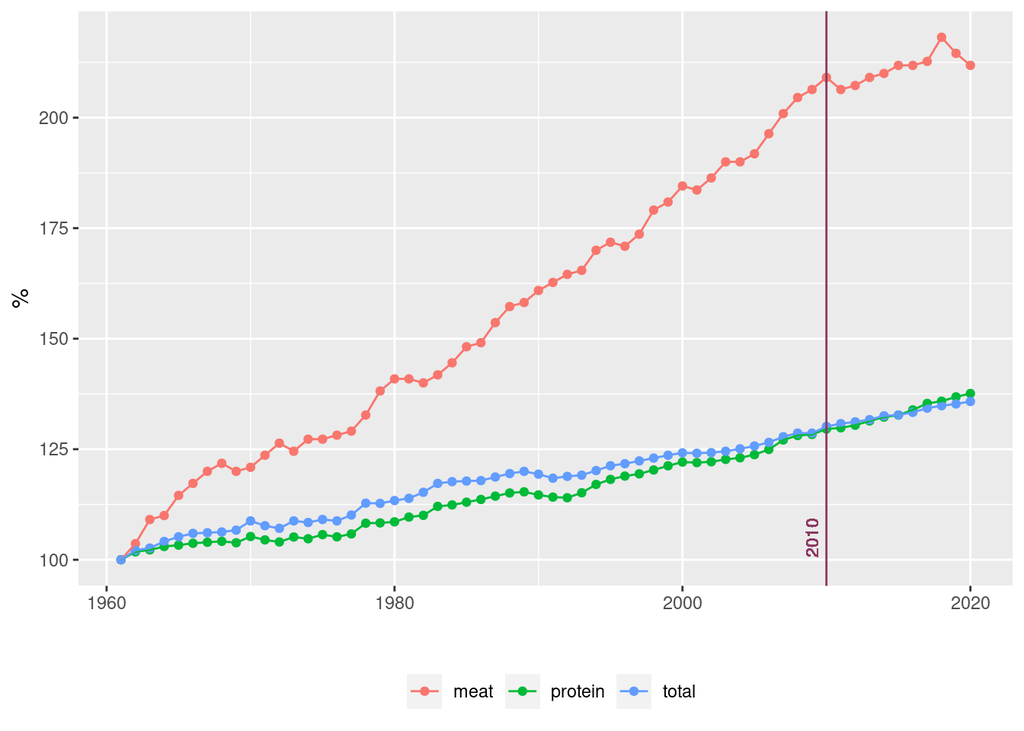

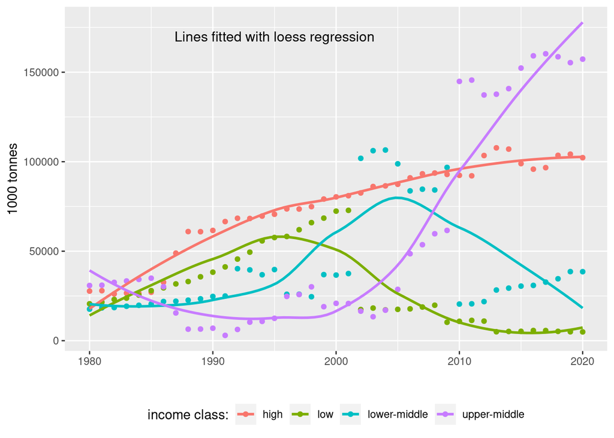

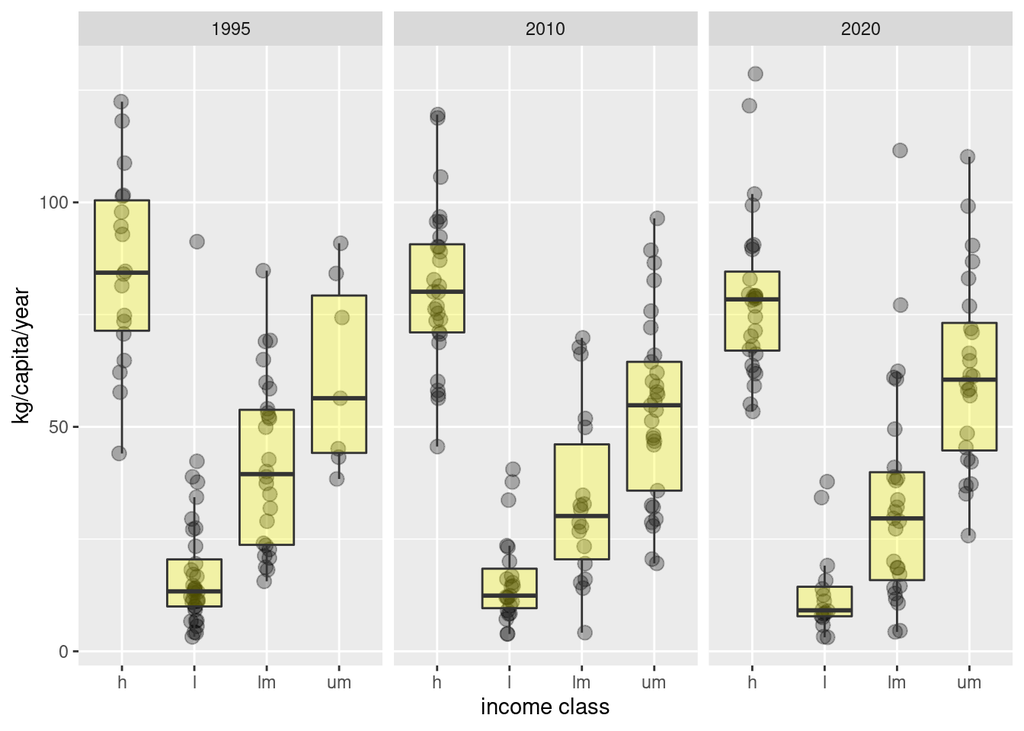

A more detailed analysis is available online in the supplementary material at author’s github repo (https://github.com/hrpunio/Papers/tree/main/PSW_2023). Detailed analysis of meat consumption over 1961–2011 period can be found in Sans and Combris (2013). Finally ten-year projection for world food consumption (including meat) can be found in OECD and Food and Agriculture Organization of the United Nations.

### Consumption-income relation

#### Environmental Kuznets Curve

The environmental Kuznets curve (EKC) is a hypothesized relationship between various indicators of environmental degradation and per capita income.

In the early stages of economic growth, pollution emissions increase and environmental quality declines, but beyond some level of per capita income the trend reverses, so that at high income levels, economic growth leads to environmental improvement.

https://www.sciencedirect.com/topics/earth-and-planetary-sciences/environmental-kuznets-curve

In case of meat consumption and the most basic form the relation can be specified as:

$$\begin{equation}
{\rm Meat} = b_0 + b_1 · {\rm GDP} + b_2 · {\rm GDP}^2
\tag{1}
\end{equation}$$

Equation (1) can be specified as

$$\begin{equation}
\ln {\rm Meat} = b_0 + b_1 · \ln {\rm GDP} + b_2 · \ln {\rm GDP}^2
\tag{2}
\end{equation}$$

If a relation between Meat consumption and GDP follows EKC it must has a turning point, ie. an income level above which the consumption of meat decreases.

Using data from 150 countries for the period 1980–2009 Cole and McCoskey (2013) claims that meat consumption follows EKC with turning point estimated at 36,4 thousad USD, that only few countries have enjoyed. In another study, Vranken et all (2014) using panel of 120 countries for the period 1970–2007 confirmed that meat consumption–income follows EKC, and estimated turning point at 32,0–55,0 thousand USD.

#### Engel curve

Alternatively to EKC we can apply another popular theory, ie. **Engel law** which assumes that consumption is under-proportional with income. This can be formally descibed by the power function with parameter $b$ which can be interpreted as an elasticity

$$\begin{equation}
M = b_0 {\rm GDP}^{b_1}
\end{equation}$$

or

$$\begin{equation}
\ln M = \ln b_0 + b_1 \cdot \ln {\rm GDP}
\tag{3}
\end{equation}$$

Note that if meat consumption follows Engel law there is no `turning point’ although meat consumption increase are every year smaller. Note also that model (3) is nested in model (2).

### Panel data analysis

Figure 4 presents scatterplots for meat consumption vs income and total intake vs income for our panel of data. (high resolution, colour charts are available online in the supplementary material)

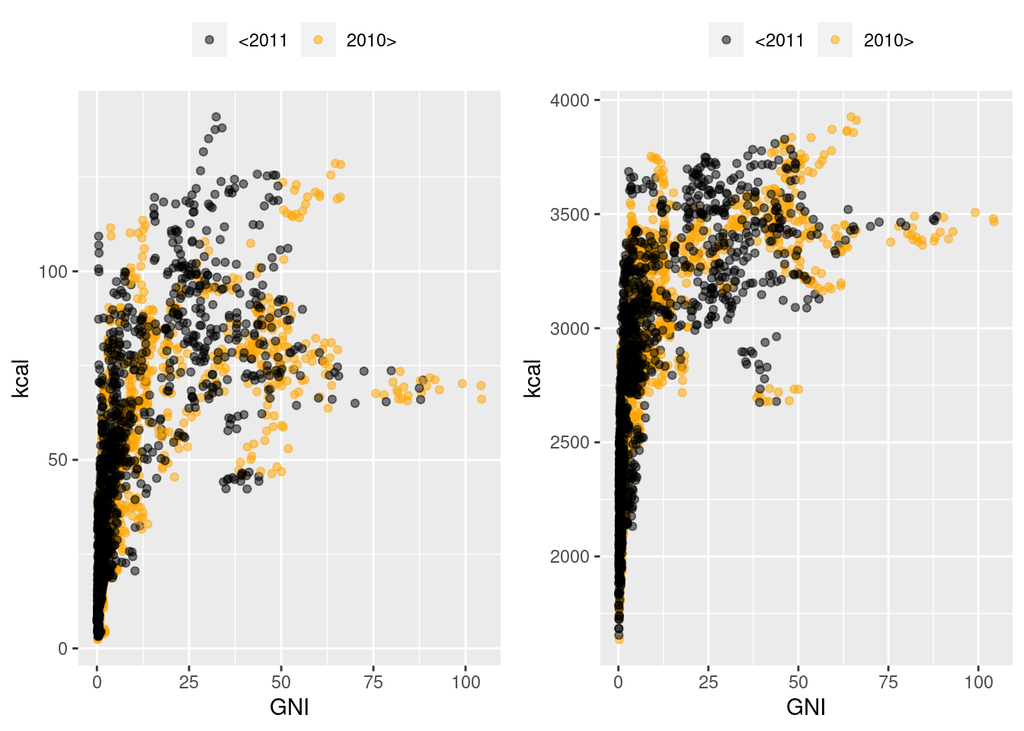

We consider model 1–3 for Meat (kg/c/y), and Total intake. All models was estimated with pooled OLS using data panel of. 102 countries for 1995–2020. Table 2 presents results.

Table 2. Meat consumption (M1–M3) and Total intake (T1–T3)

[output not shown]

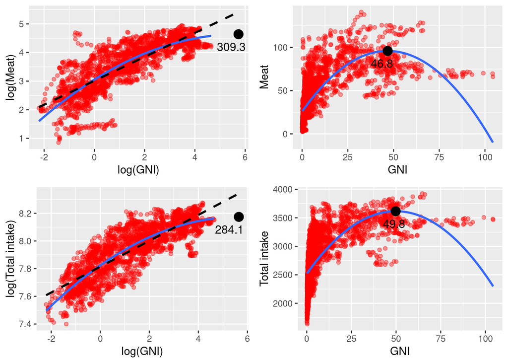

## Technical remarks

This document is an abridged version of a report prepared as R-markdown document. The source file and the data are available at author’s github repo (https://github.com/hrpunio/Papers/tree/main/PSW_2023)

## Bibliography

Cole J.R., McCoskey S., *Does global meat consumption follow an environmental Kuznets curve* Sustainability: Science, Practice, and Policy 9/2 (2013), pp. 26–36 https://www.tandfonline.com/doi/abs/10.1080/15487733.2013.11908112

Sans P., Combris P., *World meat consumption patters: An overview of the last fifty years (1961–2011)* Meat Science 2015

Stern D.I., *Environmental Kuznets Curve*, in *Encyclopedia of Energy*, Cutler J. Cleveland (editor) Elsevier Science 2004 https://www.sciencedirect.com/topics/earth-and-planetary-sciences/environmental-kuznets-curve

Stoś K., Rychlik E., Wożniak A., Ołtarzewski M., *Red and Processed Meat Consumption in Poland*, Foods 11/2022, 3283

Vrenken L., Avermaete T., Petalios D., Mathijs E., Curbing global meat consumption: Emerging evidence of a second nutrition transition, Environmental Science and Policy 39/2014, pp. 95–106

Hickel J., Kallis G., *Is Green Growth Possible?*, New Political Economy, 2020/25 issue 4, pp. 469–486

OECD and Food and Agriculture Organization of the United Nations, OECD-FAO Agricultural Outlook 2023-2032 https://doi.org/10.1787/08801ab7-en

Warlenius R.H., *The limits to degrowth: Economic and climatic consequences of pessimist assumptions on decoupling* Ecological Economics 2023/213 https://doi.org/10.1016/j.ecolecon.2023.107937